# Attention is all you need - Transformer 논문 요약

### 영어/한국어 word2vec 실습

```python
import re
from lxml import etree
import urllib.request
import zipfile
from nltk.tokenize import word_tokenize, sent_tokenize

urllib.request.urlretrieve("https://wit3.fbk.eu/get.php?path=XML_releases/xml/ted_en-20160408.zip&filename=ted_en-20160408.zip", filename="ted_en-20160408.zip")
# 데이터 다운로드

with zipfile.ZipFile('ted_en-20160408.zip', 'r') as z:
  target_text = etree.parse(z.open('ted_en-20160408.xml', 'r'))
  parse_text = '\n'.join(target_text.xpath('//content/text()'))
# xml 파일로부터 <content>와 </content> 사이의 내용만 가져온다.
```

```python
parse_text[:300]
```

```
"Here are two reasons companies fail: they only do more of the same, or they only do what's new.\nTo me the real, real solution to quality growth is figuring out the balance between two activities: exploration and exploitation. Both are necessary, but it can be too much of a good thing.\nConsider Fa…
```

```python
import nltk
nltk.download('punkt')

content_text = re.sub(r'\([^)]*\)', '', parse_text)
# 정규 표현식의 sub 모듈을 통해 content 중간에 등장하는 (Audio), (Laughter) 등의 배경음 부분을 제거.
# 해당 코드는 괄호로 구성된 내용을 제거.

sent_text=sent_tokenize(content_text)
# 입력 코퍼스에 대해서 NLTK를 이용하여 문장 토큰화를 수행.

normalized_text = []
for string in sent_text:
     tokens = re.sub(r"[^a-z0-9]+", " ", string.lower())
     normalized_text.append(tokens)
# 각 문장에 대해서 구두점을 제거하고, 대문자를 소문자로 변환.

result = [word_tokenize(sentence) for sentence in normalized_text]
# 각 문장에 대해서 NLTK를 이용하여 단어 토큰화를 수행.
print('총 샘플의 개수: {}'.format(len(result)))
```

```
총 샘플의 개수: 273424
```

```python
for line in result[:3]: # 샘플 3개만 출력
    print(line)
```

```
['here', 'are', 'two', 'reasons', 'companies', 'fail', 'they', 'only', 'do', 'more', 'of', 'the', 'same', 'or', 'they', 'only', 'do', 'what', 's', 'new']
['to', 'me', 'the', 'real', 'real', 'solution', 'to', 'quality', 'growth', 'is', 'figuring', 'out', 'the', 'balance', 'between', 'two', 'activities', 'exploration', 'and', 'exploitation']
['both', 'are', 'necessary', 'but', 'it', 'can', 'be', 'too', 'much', 'of', 'a', 'good', 'thing']
```

```python
from gensim.models import Word2Vec
model = Word2Vec(sentences=result, size=100, window=5, min_count=5, workers=4, sg=0)
model_result = model.wv.most_similar("man")
print(model_result)
```

```
[('woman', 0.8496309518814087), ('guy', 0.8047130107879639), ('lady', 0.7630440592765808), ('boy', 0.7434742450714111), ('girl', 0.7397940158843994), ('poet', 0.7102178335189819), ('gentleman', 0.6967080235481262), ('kid', 0.6860352754592896), ('soldier', 0.6833100318908691), ('surgeon', 0.676280856…
```

```python
from gensim.models import KeyedVectors
model.wv.save_word2vec_format('eng_w2v') # 모델 저장
loaded_model = KeyedVectors.load_word2vec_format("eng_w2v") # 모델 로드
```

```python
model_result = loaded_model.most_similar("man")
print(model_result)
```

```
[('woman', 0.8496309518814087), ('guy', 0.8047130107879639), ('lady', 0.7630440592765808), ('boy', 0.7434742450714111), ('girl', 0.7397940158843994), ('poet', 0.7102178335189819), ('gentleman', 0.6967080235481262), ('kid', 0.6860352754592896), ('soldier', 0.6833100318908691), ('surgeon', 0.676280856…
```

```python
!pip install konlpy
```

[output not shown]

```python
import pandas as pd
import matplotlib.pyplot as plt
import urllib.request
from gensim.models.word2vec import Word2Vec
from konlpy.tag import Okt

urllib.request.urlretrieve("https://raw.githubusercontent.com/e9t/nsmc/master/ratings.txt", filename="ratings.txt")
train_data = pd.read_table('ratings.txt')
train_data[:5]
```

|  | id | document | label |
| --- | --- | --- | --- |
| 0 | 8112052 | 어릴때보고 지금다시봐도 재밌어요ㅋㅋ | 1 |
| 1 | 8132799 | 디자인을 배우는 학생으로, 외국디자이너와 그들이 일군 전통을 통해 발전해가는 문화산... | 1 |
| 2 | 4655635 | 폴리스스토리 시리즈는 1부터 뉴까지 버릴께 하나도 없음.. 최고. | 1 |
| 3 | 9251303 | 와.. 연기가 진짜 개쩔구나.. 지루할거라고 생각했는데 몰입해서 봤다.. 그래 이런... | 1 |
| 4 | 10067386 | 안개 자욱한 밤하늘에 떠 있는 초승달 같은 영화. | 1 |

```python
print(len(train_data)) # 리뷰 개수 출력
# NULL 값 존재 유무
print(train_data.isnull().values.any())
train_data = train_data.dropna(how = 'any') # Null 값이 존재하는 행 제거
print(train_data.isnull().values.any()) # Null 값이 존재하는지 확인
print(len(train_data)) # 리뷰 개수 출력
# 정규 표현식을 통한 한글 외 문자 제거
train_data['document'] = train_data['document'].str.replace("[^ㄱ-ㅎㅏ-ㅣ가-힣 ]","")
train_data[:5] # 상위 5개 출력
```

```
200000
True
False
199992
```

|  | id | document | label |
| --- | --- | --- | --- |
| 0 | 8112052 | 어릴때보고 지금다시봐도 재밌어요ㅋㅋ | 1 |
| 1 | 8132799 | 디자인을 배우는 학생으로 외국디자이너와 그들이 일군 전통을 통해 발전해가는 문화산업... | 1 |
| 2 | 4655635 | 폴리스스토리 시리즈는 부터 뉴까지 버릴께 하나도 없음 최고 | 1 |
| 3 | 9251303 | 와 연기가 진짜 개쩔구나 지루할거라고 생각했는데 몰입해서 봤다 그래 이런게 진짜 영화지 | 1 |
| 4 | 10067386 | 안개 자욱한 밤하늘에 떠 있는 초승달 같은 영화 | 1 |

```python
# 불용어 정의
stopwords = ['의','가','이','은','들','는','좀','잘','걍','과','도','를','으로','자','에','와','한','하다']
# 형태소 분석기 OKT를 사용한 토큰화 작업 (다소 시간 소요)
okt = Okt()
tokenized_data = []
for sentence in train_data['document']:
    temp_X = okt.morphs(sentence, stem=True) # 토큰화
    temp_X = [word for word in temp_X if not word in stopwords] # 불용어 제거
    tokenized_data.append(temp_X)
# 리뷰 길이 분포 확인
print('리뷰의 최대 길이 :',max(len(l) for l in tokenized_data))
print('리뷰의 평균 길이 :',sum(map(len, tokenized_data))/len(tokenized_data))
plt.hist([len(s) for s in tokenized_data], bins=50)
plt.xlabel('length of samples')
plt.ylabel('number of samples')
plt.show()
```

[output not shown]

```python
from gensim.models import Word2Vec
model = Word2Vec(sentences = tokenized_data, size = 100, window = 5, min_count = 5, workers = 4, sg = 0)
# 완성된 임베딩 매트릭스의 크기 확인
model.wv.vectors.shape
print(model.wv.most_similar("최민식"))
print(model.wv.most_similar("히어로"))
```

[output not shown]

### 워드투벡 구현하기

```python
from sklearn.datasets import fetch_20newsgroups
import pandas as pd
import numpy as np
import nltk
from nltk.corpus import stopwords
from tensorflow.keras.preprocessing.text import Tokenizer
```

```python
dataset = fetch_20newsgroups(shuffle=True, random_state=1, remove=('headers', 'footers', 'quotes'))
documents = dataset.data
print('총 샘플 수 :',len(documents))
```

```
Downloading 20news dataset. This may take a few minutes.
Downloading dataset from https://ndownloader.figshare.com/files/5975967 (14 MB)
```

```
총 샘플 수 : 11314
```

```python
news_df = pd.DataFrame({'document':documents})
# 특수 문자 제거
news_df['clean_doc'] = news_df['document'].str.replace("[^a-zA-Z]", " ")
# 길이가 3이하인 단어는 제거 (길이가 짧은 단어 제거)
news_df['clean_doc'] = news_df['clean_doc'].apply(lambda x: ' '.join([w for w in x.split() if len(w)>3]))
# 전체 단어에 대한 소문자 변환
news_df['clean_doc'] = news_df['clean_doc'].apply(lambda x: x.lower())
# null value 확인
news_df.isnull().values.any()
```

```
False
```

```python
# empty value 확인
news_df.replace("", float("NaN"), inplace=True)
news_df.isnull().values.any()
```

```
True
```

```python
# null값 제거
news_df.dropna(inplace=True)
print('총 샘플 수 :',len(news_df))
```

```
총 샘플 수 : 10995
```

```python
import nltk
nltk.download('stopwords')
# 불용어를 제거
stop_words = stopwords.words('english')
tokenized_doc = news_df['clean_doc'].apply(lambda x: x.split())
tokenized_doc = tokenized_doc.apply(lambda x: [item for item in x if item not in stop_words])
tokenized_doc = tokenized_doc.to_list()
```

```python
# 단어가 1개 이하인 샘플의 인덱스를 찾아서 저장하고, 해당 샘플들은 제거.
drop_train = [index for index, sentence in enumerate(tokenized_doc) if len(sentence) <= 1]
tokenized_doc = np.delete(tokenized_doc, drop_train, axis=0)
print('총 샘플 수 :',len(tokenized_doc))
```

```
총 샘플 수 : 10940
```

```python
# 정수인코딩
tokenizer = Tokenizer()
tokenizer.fit_on_texts(tokenized_doc)

word2idx = tokenizer.word_index
idx2word = {v:k for k, v in word2idx.items()}
encoded = tokenizer.texts_to_sequences(tokenized_doc)
```

```python
print(encoded[:2])
```

```
[[9, 59, 603, 207, 3278, 1495, 474, 702, 9470, 13686, 5533, 15227, 702, 442, 702, 70, 1148, 1095, 1036, 20294, 984, 705, 4294, 702, 217, 207, 1979, 15228, 13686, 4865, 4520, 87, 1530, 6, 52, 149, 581, 661, 4406, 4988, 4866, 1920, 755, 10668, 1102, 7837, 442, 957, 10669, 634, 51, 228, 2669, 4989, 178…
```

```python
vocab_size = len(word2idx) + 1
print('단어 집합의 크기 :', vocab_size)
```

```
단어 집합의 크기 : 64277
```

```python
from tensorflow.keras.preprocessing.sequence import skipgrams
# 네거티브 샘플링
skip_grams = [skipgrams(sample, vocabulary_size=vocab_size, window_size=10) for sample in encoded[:10]]
# 첫번째 샘플인 skip_grams[0] 내 skipgrams로 형성된 데이터셋 확인
pairs, labels = skip_grams[0][0], skip_grams[0][1]
for i in range(5):
    print("({:s} ({:d}), {:s} ({:d})) -> {:d}".format(
          idx2word[pairs[i][0]], pairs[i][0],
          idx2word[pairs[i][1]], pairs[i][1],
          labels[i]))
```

```
(least (87), wefl (54068)) -> 0
(government (51), look (66)) -> 1
(degree (1530), magaziner (39612)) -> 0
(subsidizing (15228), least (87)) -> 1
(europeans (4520), subsidizing (15228)) -> 1
```

```python
print('전체 샘플 수 :',len(skip_grams))
```

```
전체 샘플 수 : 10
```

```python
# 첫번째 뉴스그룹 샘플에 대해서 생긴 pairs와 labels의 개수
print(len(pairs))
print(len(labels))
```

```
2220
2220
```

```python
skip_grams = [skipgrams(sample, vocabulary_size=vocab_size, window_size=10) for sample in encoded]
```

```
Model: "functional_1"
__________________________________________________________________________________________________
Layer (type)                    Output Shape         Param #     Connected to
==================================================================================================
input_1 (InputLayer)            [(None, 1)]          0
__________________________________________________________________________________________________
input_2 (InputLayer)            [(None, 1)]          0
__________________________________________________________________________________________________
embedding (Embedding)           (None, 1, 100)       6427700     input_1[0][0]
__________________________________________________________________________________________________
embedding_1 (Embedding)         (None, 1, 100)       6427700     input_2[0][0]
__________________________________________________________________________________________________
dot (Dot)                       (None, 1, 1)         0           embedding[0][0]
                                                                 embedding_1[0][0]
__________________________________________________________________________________________________
reshape (Reshape)               (None, 1)            0           dot[0][0]
__________________________________________________________________________________________________
activation (Activation)         (None, 1)            0           reshape[0][0]
==================================================================================================
Total params: 12,855,400
Trainable params: 12,855,400
Non-trainable params: 0
__________________________________________________________________________________________________
```

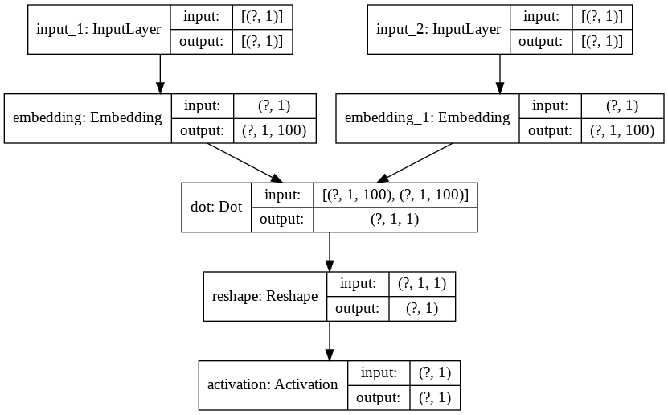

```python
from tensorflow.keras.models import Sequential, Model
from tensorflow.keras.layers import Embedding, Reshape, Activation, Input
from tensorflow.keras.layers import Dot
from tensorflow.keras.utils import plot_model
from IPython.display import SVG

embed_size = 100

# 모델 설계
# 중심 단어를 위한 임베딩 테이블
w_inputs = Input(shape=(1, ), dtype='int32')
word_embedding = Embedding(vocab_size, embed_size)(w_inputs)

# 주변 단어를 위한 임베딩 테이블
c_inputs = Input(shape=(1, ), dtype='int32')
context_embedding  = Embedding(vocab_size, embed_size)(c_inputs)

# 임베딩테이블 생성, 시그모이드->활성화함수->예측값
dot_product = Dot(axes=2)([word_embedding, context_embedding])
dot_product = Reshape((1,), input_shape=(1, 1))(dot_product)
output = Activation('sigmoid')(dot_product)
model = Model(inputs=[w_inputs, c_inputs], outputs=output)
model.summary()
model.compile(loss='binary_crossentropy', optimizer='adam')
plot_model(model, to_file='model3.png', show_shapes=True, show_layer_names=True, rankdir='TB')
```

```python
for epoch in range(1, 6):
    loss = 0
    for _, elem in enumerate(skip_grams):
        first_elem = np.array(list(zip(*elem[0]))[0], dtype='int32')
        second_elem = np.array(list(zip(*elem[0]))[1], dtype='int32')
        labels = np.array(elem[1], dtype='int32')
        X = [first_elem, second_elem]
        Y = labels
        loss += model.train_on_batch(X,Y)
    print('Epoch :',epoch, 'Loss :',loss)
```

[output not shown]

```python
import gensim
f = open('vectors.txt' ,'w')
f.write('{} {}\n'.format(vocab_size-1, embed_size))
vectors = model.get_weights()[0]
for word, i in tokenizer.word_index.items():
    f.write('{} {}\n'.format(word, ' '.join(map(str, list(vectors[i, :])))))
f.close()
w2v = gensim.models.KeyedVectors.load_word2vec_format('./vectors.txt', binary=False)
w2v.most_similar(positive=['soldiers'])
w2v.most_similar(positive=['doctor'])
w2v.most_similar(positive=['police'])
w2v.most_similar(positive=['knife'])
w2v.most_similar(positive=['engine'])
```

[output not shown]

## 글로브(Glove)

- 카운트 기반과 예측 기반을 모두 사용하는 방법론으로 단어 임베딩 방법론임.
- LSA와 예측기반의 word2vec의 단점을 지적하며 나타났고, 뛰어난 성능을 보여주고 있음.

### 기존방법론에 대한 비판

LSA는 DTM이나 TF-IDF 행렬과 같이 각 문서에서의 각 단어의 빈도수를 카운트 한 행렬이라는 전체적인 통계 정보를 입력으로 받아 차원을 축소(Truncated SVD)하여 잠재된 의미를 끌어내는 방법론. 반면, Word2Vec는 실제값과 예측값에 대한 오차를 손실 함수를 통해 줄여나가며 학습하는 예측 기반의 방법론.

LSA는 카운트 기반으로 코퍼스의 전체적인 통계 정보를 고려하기는 하지만, 왕:남자 = 여왕:? (정답은 여자)와 같은 단어 의미의 유추 작업(Analogy task)에는 성능이 떨어진다. Word2Vec는 예측 기반으로 단어 간 유추 작업에는 LSA보다 뛰어나지만, 임베딩 벡터가 윈도우 크기 내에서만 주변 단어를 고려하기 때문에 코퍼스의 전체적인 통계 정보를 반영하지 못함.

GloVe는 이러한 기존 방법론들의 각각의 한계를 지적하며, LSA의 메커니즘이었던 카운트 기반의 방법과 Word2Vec의 메커니즘이었던 예측 기반의 방법론 두 가지를 모두 사용함.

### 윈도우 기반 동시 등장 행렬

- 행과 열을 전체 단어집합의 단어들로 구성하고, i단어의 윈도우 크기 내에서 k 단어가 등장한 횟수를 i행 k열에 기재한 행렬임.

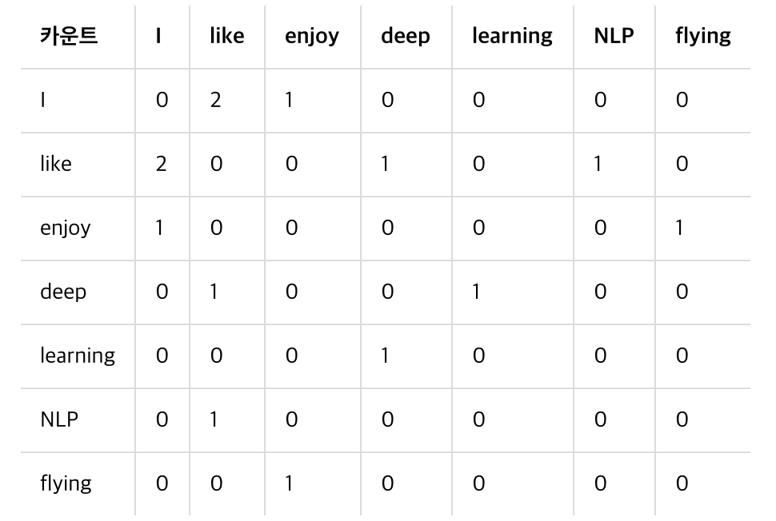

### 동시 등장 확률

- P(k | i)는 특정 단어 i의 전체 등장 횟수를 카운트하고 i가 등장했을 때 어떤 단어 k가 등장한 횟수를 카운트하여 계산한 조건부확률임.
- P(k | i)에서 i를 중심 단어(Center Word), k를 주변 단어(Context Word)라고 했을 때, 위에서 배운 동시 등장 행렬에서 중심 단어 i의 행의 모든 값을 더한 값을 분모로 하고 i행 k열의 값을 분자로 한 값.

### 손실함수

- '임베딩 된 중심단어와 주변 단어 벡터의 내적이 전체 코퍼스에서의 동시 등장 확률이 되도록 만드는 것'

## 사전훈련된 워드임베딩

### 임베딩 층은 룩업테이블이다.

- 임베딩 층의 입력으로 사용하기 위해서는 입력시퀀스의 각 단어들이 모두 정수 인코딩 되어있어야 합니다.

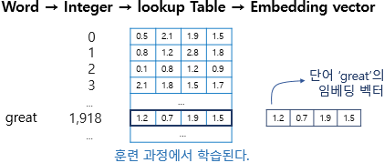

```python
from tensorflow.keras.preprocessing.text import Tokenizer
from tensorflow.keras.preprocessing.sequence import pad_sequences
import numpy as np

sentences = ['nice great best amazing', 'stop lies', 'pitiful nerd', 'excellent work', 'supreme quality', 'bad', 'highly respectable']
y_train = [1, 0, 0, 1, 1, 0, 1]

t = Tokenizer()
t.fit_on_texts(sentences)
vocab_size = len(t.word_index) + 1

print(vocab_size)

X_encoded = t.texts_to_sequences(sentences)
print(X_encoded)
```

```
16
[[1, 2, 3, 4], [5, 6], [7, 8], [9, 10], [11, 12], [13], [14, 15]]
```

```python
# 정수인코딩
max_len=max(len(l) for l in X_encoded)
print(max_len)
X_train=pad_sequences(X_encoded, maxlen=max_len, padding='post')
y_train=np.array(y_train)
print(X_train)
```

```
4
[[ 1  2  3  4]
 [ 5  6  0  0]
 [ 7  8  0  0]
 [ 9 10  0  0]
 [11 12  0  0]
 [13  0  0  0]
 [14 15  0  0]]
```

```python
# 모델 설계

from tensorflow.keras.models import Sequential
from tensorflow.keras.layers import Dense, Embedding, Flatten

model = Sequential()
model.add(Embedding(vocab_size, 4, input_length=max_len)) # 모든 임베딩 벡터는 4차원.
model.add(Flatten()) # Dense의 입력으로 넣기위함.
model.add(Dense(1, activation='sigmoid'))
```

```python
# 시그모이드를 활성화함수로 사용, 이진분류 수행
model.compile(optimizer='adam', loss='binary_crossentropy', metrics=['acc'])
model.fit(X_train, y_train, epochs=100, verbose=2)
```

```
1/1 - 0s - loss: 0.6994 - acc: 0.4286
1/1 - 0s - loss: 0.6979 - acc: 0.4286
1/1 - 0s - loss: 0.6965 - acc: 0.5714
1/1 - 0s - loss: 0.6951 - acc: 0.5714
1/1 - 0s - loss: 0.6936 - acc: 0.5714
1/1 - 0s - loss: 0.6922 - acc: 0.5714
1/1 - 0s - loss: 0.6908 - acc: 0.7143
1/1 - 0s - loss: 0.6894 - acc: 0.7143
1/1 - 0s - loss: 0.6880 - acc: 0.7143
1/1 - 0s - loss: 0.6866 - acc: 0.7143
1/1 - 0s - loss: 0.6852 - acc: 0.7143
1/1 - 0s - loss: 0.6838 - acc: 0.7143
1/1 - 0s - loss: 0.6824 - acc: 0.8571
1/1 - 0s - loss: 0.6810 - acc: 0.8571
1/1 - 0s - loss: 0.6796 - acc: 0.8571
1/1 - 0s - loss: 0.6782 - acc: 0.8571
1/1 - 0s - loss: 0.6768 - acc: 0.8571
1/1 - 0s - loss: 0.6754 - acc: 0.8571
1/1 - 0s - loss: 0.6740 - acc: 1.0000
1/1 - 0s - loss: 0.6726 - acc: 1.0000
1/1 - 0s - loss: 0.6712 - acc: 1.0000
1/1 - 0s - loss: 0.6698 - acc: 1.0000
1/1 - 0s - loss: 0.6684 - acc: 1.0000
1/1 - 0s - loss: 0.6669 - acc: 1.0000
1/1 - 0s - loss: 0.6655 - acc: 1.0000
1/1 - 0s - loss: 0.6641 - acc: 1.0000
1/1 - 0s - loss: 0.6626 - acc: 1.0000
1/1 - 0s - loss: 0.6612 - acc: 1.0000
1/1 - 0s - loss: 0.6597 - acc: 1.0000
1/1 - 0s - loss: 0.6583 - acc: 1.0000
1/1 - 0s - loss: 0.6568 - acc: 1.0000
1/1 - 0s - loss: 0.6553 - acc: 1.0000
1/1 - 0s - loss: 0.6538 - acc: 1.0000
1/1 - 0s - loss: 0.6523 - acc: 1.0000
1/1 - 0s - loss: 0.6508 - acc: 1.0000
1/1 - 0s - loss: 0.6493 - acc: 1.0000
1/1 - 0s - loss: 0.6478 - acc: 1.0000
1/1 - 0s - loss: 0.6462 - acc: 1.0000
1/1 - 0s - loss: 0.6447 - acc: 1.0000
1/1 - 0s - loss: 0.6431 - acc: 1.0000
```

[output cut: 45 more lines]

```
1/1 - 0s - loss: 0.5614 - acc: 1.0000
1/1 - 0s - loss: 0.5594 - acc: 1.0000
1/1 - 0s - loss: 0.5574 - acc: 1.0000
1/1 - 0s - loss: 0.5554 - acc: 1.0000
1/1 - 0s - loss: 0.5534 - acc: 1.0000
1/1 - 0s - loss: 0.5514 - acc: 1.0000
1/1 - 0s - loss: 0.5494 - acc: 1.0000
1/1 - 0s - loss: 0.5474 - acc: 1.0000
1/1 - 0s - loss: 0.5454 - acc: 1.0000
1/1 - 0s - loss: 0.5433 - acc: 1.0000
1/1 - 0s - loss: 0.5413 - acc: 1.0000
1/1 - 0s - loss: 0.5393 - acc: 1.0000
1/1 - 0s - loss: 0.5372 - acc: 1.0000
1/1 - 0s - loss: 0.5352 - acc: 1.0000
1/1 - 0s - loss: 0.5331 - acc: 1.0000
```

```
<tensorflow.python.keras.callbacks.History at 0x7fad4b4b2d68>
```

```python
print(X_train)
print(y_train)
```

```
[[ 1  2  3  4]
 [ 5  6  0  0]
 [ 7  8  0  0]
 [ 9 10  0  0]
 [11 12  0  0]
 [13  0  0  0]
 [14 15  0  0]]
[1 0 0 1 1 0 1]
```

```python
!wget http://nlp.stanford.edu/data/glove.6B.zip
!unzip glove*.zip
```

[output not shown]

```python
n=0
f = open('glove.6B.100d.txt', encoding="utf8")

for line in f:
    word_vector = line.split() # 각 줄을 읽어와서 word_vector에 저장.
    print(word_vector) # 각 줄을 출력
    word = word_vector[0] # word_vector에서 첫번째 값만 저장
    print(word) # word_vector의 첫번째 값만 출력
    n=n+1
    if n==2:
        break
f.close()

print(type(word_vector))
print(len(word_vector))
```

```
['the', '-0.038194', '-0.24487', '0.72812', '-0.39961', '0.083172', '0.043953', '-0.39141', '0.3344', '-0.57545', '0.087459', '0.28787', '-0.06731', '0.30906', '-0.26384', '-0.13231', '-0.20757', '0.33395', '-0.33848', '-0.31743', '-0.48336', '0.1464', '-0.37304', '0.34577', '0.052041', '0.44946', '…
the
[',', '-0.10767', '0.11053', '0.59812', '-0.54361', '0.67396', '0.10663', '0.038867', '0.35481', '0.06351', '-0.094189', '0.15786', '-0.81665', '0.14172', '0.21939', '0.58505', '-0.52158', '0.22783', '-0.16642', '-0.68228', '0.3587', '0.42568', '0.19021', '0.91963', '0.57555', '0.46185', '0.42363', …
,
<class 'list'>
101
```

```python
import numpy as np
embedding_dict = dict()
f = open('glove.6B.100d.txt', encoding="utf8")

for line in f:
    word_vector = line.split()
    word = word_vector[0]
    word_vector_arr = np.asarray(word_vector[1:], dtype='float32') # 100개의 값을 가지는 array로 변환
    embedding_dict[word] = word_vector_arr
f.close()
print('%s개의 Embedding vector가 있습니다.' % len(embedding_dict))
print(embedding_dict['respectable'])
print(len(embedding_dict['respectable']))

embedding_matrix = np.zeros((vocab_size, 100))
# 단어 집합 크기의 행과 100개의 열을 가지는 행렬 생성. 값은 전부 0으로 채워진다.
np.shape(embedding_matrix)
print(t.word_index.items())

for word, i in t.word_index.items(): # 훈련 데이터의 단어 집합에서 단어를 1개씩 꺼내온다.
    temp = embedding_dict.get(word) # 단어(key) 해당되는 임베딩 벡터의 100개의 값(value)를 임시 변수에 저장
    if temp is not None:
        embedding_matrix[i] = temp # 임수 변수의 값을 단어와 맵핑되는 인덱스의 행에 삽입
```

```
400000개의 Embedding vector가 있습니다.
[-0.049773   0.19903    0.10585    0.1391    -0.32395    0.44053
  0.3947    -0.22805   -0.25793    0.49768    0.15384   -0.08831
  0.0782    -0.8299    -0.037788   0.16772   -0.45197   -0.17085
  0.74756    0.98256    0.81872    0.28507    0.16178   -0.48626
 -0.006265  -0.92469   -0.30625   -0.067318  -0.046762  -0.76291
 -0.0025264 -0.018795   0.12882   -0.52457    0.3586     0.43119
 -0.89477   -0.057421  -0.53724    0.25587    0.55195    0.44698
 -0.24252    0.29946    0.25776   -0.8717     0.68426   -0.05688
 -0.1848    -0.59352   -0.11227   -0.57692   -0.013593   0.18488
 -0.32507   -0.90171    0.17672    0.075601   0.54896   -0.21488
 -0.54018   -0.45882   -0.79536    0.26331    0.18879   -0.16363
  0.3975     0.1099     0.1164    -0.083499   0.50159    0.35802
  0.25677    0.088546   0.42108    0.28674   -0.71285   -0.82915
  0.15297   -0.82712    0.022112   1.067     -0.31776    0.1211
 -0.069755  -0.61327    0.27308   -0.42638   -0.085084  -0.17694
 -0.0090944  0.1109     0.62543   -0.23682   -0.44928   -0.3667
 -0.21616   -0.19187   -0.032502   0.38025  ]
100
dict_items([('nice', 1), ('great', 2), ('best', 3), ('amazing', 4), ('stop', 5), ('lies', 6), ('pitiful', 7), ('nerd', 8), ('excellent', 9), ('work', 10), ('supreme', 11), ('quality', 12), ('bad', 13), ('highly', 14), ('respectable', 15)])
```

```python
from tensorflow.keras.models import Sequential
from tensorflow.keras.layers import Dense, Embedding, Flatten

model = Sequential()
e = Embedding(vocab_size, 100, weights=[embedding_matrix], input_length=max_len, trainable=False)

model.add(e)
model.add(Flatten())
model.add(Dense(1, activation='sigmoid'))
model.compile(optimizer='adam', loss='binary_crossentropy', metrics=['acc'])
model.fit(X_train, y_train, epochs=100, verbose=2)
```

```
1/1 - 0s - loss: 0.6723 - acc: 0.4286
1/1 - 0s - loss: 0.6529 - acc: 0.5714
1/1 - 0s - loss: 0.6343 - acc: 0.5714
1/1 - 0s - loss: 0.6164 - acc: 0.5714
1/1 - 0s - loss: 0.5993 - acc: 0.5714
1/1 - 0s - loss: 0.5828 - acc: 0.5714
1/1 - 0s - loss: 0.5670 - acc: 0.7143
1/1 - 0s - loss: 0.5519 - acc: 0.7143
1/1 - 0s - loss: 0.5373 - acc: 0.7143
1/1 - 0s - loss: 0.5234 - acc: 0.7143
1/1 - 0s - loss: 0.5100 - acc: 0.7143
1/1 - 0s - loss: 0.4971 - acc: 0.7143
1/1 - 0s - loss: 0.4847 - acc: 1.0000
1/1 - 0s - loss: 0.4727 - acc: 1.0000
1/1 - 0s - loss: 0.4612 - acc: 1.0000
1/1 - 0s - loss: 0.4500 - acc: 1.0000
1/1 - 0s - loss: 0.4392 - acc: 1.0000
1/1 - 0s - loss: 0.4288 - acc: 1.0000
1/1 - 0s - loss: 0.4187 - acc: 1.0000
1/1 - 0s - loss: 0.4089 - acc: 1.0000
1/1 - 0s - loss: 0.3994 - acc: 1.0000
1/1 - 0s - loss: 0.3902 - acc: 1.0000
1/1 - 0s - loss: 0.3812 - acc: 1.0000
1/1 - 0s - loss: 0.3725 - acc: 1.0000
1/1 - 0s - loss: 0.3641 - acc: 1.0000
1/1 - 0s - loss: 0.3559 - acc: 1.0000
1/1 - 0s - loss: 0.3479 - acc: 1.0000
1/1 - 0s - loss: 0.3401 - acc: 1.0000
1/1 - 0s - loss: 0.3326 - acc: 1.0000
1/1 - 0s - loss: 0.3253 - acc: 1.0000
1/1 - 0s - loss: 0.3182 - acc: 1.0000
1/1 - 0s - loss: 0.3112 - acc: 1.0000
1/1 - 0s - loss: 0.3045 - acc: 1.0000
1/1 - 0s - loss: 0.2979 - acc: 1.0000
1/1 - 0s - loss: 0.2916 - acc: 1.0000
1/1 - 0s - loss: 0.2854 - acc: 1.0000
1/1 - 0s - loss: 0.2793 - acc: 1.0000
1/1 - 0s - loss: 0.2735 - acc: 1.0000
1/1 - 0s - loss: 0.2678 - acc: 1.0000
1/1 - 0s - loss: 0.2622 - acc: 1.0000
```

[output cut: 45 more lines]

```
1/1 - 0s - loss: 0.1186 - acc: 1.0000
1/1 - 0s - loss: 0.1169 - acc: 1.0000
1/1 - 0s - loss: 0.1153 - acc: 1.0000
1/1 - 0s - loss: 0.1137 - acc: 1.0000
1/1 - 0s - loss: 0.1122 - acc: 1.0000
1/1 - 0s - loss: 0.1107 - acc: 1.0000
1/1 - 0s - loss: 0.1092 - acc: 1.0000
1/1 - 0s - loss: 0.1077 - acc: 1.0000
1/1 - 0s - loss: 0.1063 - acc: 1.0000
1/1 - 0s - loss: 0.1049 - acc: 1.0000
1/1 - 0s - loss: 0.1036 - acc: 1.0000
1/1 - 0s - loss: 0.1022 - acc: 1.0000
1/1 - 0s - loss: 0.1009 - acc: 1.0000
1/1 - 0s - loss: 0.0997 - acc: 1.0000
1/1 - 0s - loss: 0.0984 - acc: 1.0000
```

```
<tensorflow.python.keras.callbacks.History at 0x7fad45137be0>
```

```python
import numpy as np
import gensim

# 현재 위치에 구글의 사전 훈련된 Word2Vec을 다운로드
!wget "https://s3.amazonaws.com/dl4j-distribution/GoogleNews-vectors-negative300.bin.gz"

# 구글의 사전 훈련된 Word2vec 모델을 로드합니다.
word2vec_model = gensim.models.KeyedVectors.load_word2vec_format('GoogleNews-vectors-negative300.bin.gz', binary=True)

print(word2vec_model.vectors.shape) # 모델의 크기 확인

embedding_matrix = np.zeros((vocab_size, 300))
# 단어 집합 크기의 행과 300개의 열을 가지는 행렬 생성. 값은 전부 0으로 채워진다.
np.shape(embedding_matrix)

def get_vector(word):
    if word in word2vec_model:
        return word2vec_model[word]
    else:
        return None

for word, i in t.word_index.items(): # 훈련 데이터의 단어 집합에서 단어와 정수 인덱스를 1개씩 꺼내온다.
    temp = get_vector(word) # 단어(key) 해당되는 임베딩 벡터의 300개의 값(value)를 임시 변수에 저장
    if temp is not None: # 만약 None이 아니라면 임베딩 벡터의 값을 리턴받은 것이므로
        embedding_matrix[i] = temp # 해당 단어 위치의 행에 벡터의 값을 저장한다.

print(word2vec_model['nice'])

print('단어 nice의 정수 인덱스 :', t.word_index['nice'])

print(embedding_matrix[1])
```

[output not shown]

```
(3000000, 300)
[ 0.15820312  0.10595703 -0.18945312  0.38671875  0.08349609 -0.26757812
  0.08349609  0.11328125 -0.10400391  0.17871094 -0.12353516 -0.22265625
 -0.01806641 -0.25390625  0.13183594  0.0859375   0.16113281  0.11083984
 -0.11083984 -0.0859375   0.0267334   0.34570312  0.15136719 -0.00415039
  0.10498047  0.04907227 -0.06982422  0.08642578  0.03198242 -0.02844238
 -0.15722656  0.11865234  0.36132812  0.00173187  0.05297852 -0.234375
  0.11767578  0.08642578 -0.01123047  0.25976562  0.28515625 -0.11669922
  0.38476562  0.07275391  0.01147461  0.03466797  0.18164062 -0.03955078
  0.04199219  0.01013184 -0.06054688  0.09765625  0.06689453  0.14648438
 -0.12011719  0.08447266 -0.06152344  0.06347656  0.3046875  -0.35546875
 -0.2890625   0.19628906 -0.33203125 -0.07128906  0.12792969  0.09619141
 -0.12158203 -0.08691406 -0.12890625  0.27734375  0.265625    0.1796875
  0.12695312  0.06298828 -0.34375    -0.05908203  0.0456543   0.171875
  0.08935547  0.14648438 -0.04638672 -0.00842285 -0.0279541   0.234375
 -0.07470703 -0.13574219  0.00378418  0.19433594  0.05664062 -0.05419922
  0.06176758  0.14160156 -0.24121094  0.02539062 -0.15917969 -0.10595703
  0.11865234  0.24707031 -0.13574219 -0.20410156 -0.30078125  0.07910156
 -0.04394531  0.02026367 -0.05786133  0.2109375   0.13574219  0.08349609
 -0.0098877  -0.10546875 -0.08105469  0.03735352 -0.10351562 -0.10205078
  0.23925781 -0.21875     0.05151367  0.06738281  0.07617188  0.04638672
  0.03198242 -0.07275391  0.14550781  0.04858398 -0.05664062 -0.07470703
 -0.0030365  -0.09277344 -0.11083984 -0.03320312 -0.15234375 -0.12207031
  0.09814453  0.375       0.00454712 -0.10009766  0.02734375  0.30078125
 -0.0390625   0.30078125 -0.04541016 -0.00424194  0.13671875 -0.18945312
 -0.21777344  0.12695312 -0.02746582 -0.18164062  0.08984375 -0.23339844
  0.203125    0.2734375  -0.26953125  0.15332031 -0.20703125 -0.01153564
  0.12451172  0.05395508 -0.23535156 -0.01409912 -0.09765625  0.20800781
  0.19335938  0.14746094  0.28710938 -0.23046875  0.01965332 -0.09619141
 -0.0703125  -0.04174805 -0.17578125  0.0007019   0.10546875  0.10351562
  0.02478027  0.35742188  0.17382812 -0.09570312 -0.18359375  0.23242188
 -0.14453125 -0.20410156 -0.01867676  0.06640625 -0.2265625  -0.00582886
 -0.08642578  0.02416992 -0.07324219 -0.29882812 -0.15625     0.07666016
  0.19628906 -0.20410156  0.09863281 -0.01672363 -0.18652344 -0.12353516
 -0.16015625 -0.10058594  0.21777344  0.09375    -0.10058594 -0.03637695
  0.15136719 -0.02526855 -0.23730469  0.03417969 -0.00604248  0.15625
 -0.14257812  0.18066406 -0.35351562  0.25        0.13085938 -0.04296875
  0.17089844  0.20507812  0.00680542 -0.08251953 -0.06738281  0.22167969
 -0.16308594 -0.16699219 -0.02087402  0.11035156  0.06054688 -0.04223633
 -0.17285156  0.05029297 -0.19824219  0.01495361  0.06542969  0.03271484
```

[output cut: 47 more lines]

```
 -0.14257812  0.18066406 -0.35351562  0.25        0.13085938 -0.04296875
  0.17089844  0.20507812  0.00680542 -0.08251953 -0.06738281  0.22167969
 -0.16308594 -0.16699219 -0.02087402  0.11035156  0.06054688 -0.04223633
 -0.17285156  0.05029297 -0.19824219  0.01495361  0.06542969  0.03271484
  0.14453125 -0.08691406 -0.11035156 -0.1484375   0.09667969  0.22363281
  0.23535156  0.08398438  0.18164062 -0.10595703 -0.04296875  0.11572266
 -0.00153351  0.0534668  -0.1328125  -0.33203125 -0.08251953  0.30664062
  0.22363281  0.27929688  0.09082031 -0.18066406 -0.00613403 -0.09423828
 -0.21289062  0.01965332 -0.08105469 -0.06689453 -0.31835938 -0.08447266
  0.13574219  0.0625      0.07080078 -0.14257812 -0.11279297  0.01452637
 -0.06689453  0.03881836  0.19433594  0.09521484  0.11376953 -0.12451172
  0.13769531 -0.18847656 -0.05224609  0.15820312  0.09863281 -0.04370117
 -0.06054688  0.21679688  0.04077148 -0.14648438 -0.18945312 -0.25195312
 -0.16894531 -0.08642578 -0.08544922  0.18945312 -0.14648438  0.13476562
 -0.04077148  0.03271484  0.08935547 -0.26757812  0.00836182 -0.21386719]
```

```python
from tensorflow.keras.models import Sequential
from tensorflow.keras.layers import Dense, Embedding, Flatten

model = Sequential()
e = Embedding(vocab_size, 300, weights=[embedding_matrix], input_length=max_len, trainable=False)
model.add(e)
model.add(Flatten())
model.add(Dense(1, activation='sigmoid'))
model.compile(optimizer='adam', loss='binary_crossentropy', metrics=['acc'])
model.fit(X_train, y_train, epochs=100, verbose=2)
```

```
1/1 - 0s - loss: 0.7057 - acc: 0.5714
1/1 - 0s - loss: 0.6868 - acc: 0.5714
1/1 - 0s - loss: 0.6683 - acc: 0.7143
1/1 - 0s - loss: 0.6504 - acc: 0.7143
1/1 - 0s - loss: 0.6331 - acc: 0.7143
1/1 - 0s - loss: 0.6163 - acc: 0.7143
1/1 - 0s - loss: 0.6001 - acc: 0.7143
1/1 - 0s - loss: 0.5844 - acc: 0.7143
1/1 - 0s - loss: 0.5693 - acc: 0.7143
1/1 - 0s - loss: 0.5547 - acc: 0.7143
1/1 - 0s - loss: 0.5406 - acc: 0.8571
1/1 - 0s - loss: 0.5270 - acc: 0.8571
1/1 - 0s - loss: 0.5138 - acc: 0.8571
1/1 - 0s - loss: 0.5012 - acc: 0.8571
1/1 - 0s - loss: 0.4889 - acc: 0.8571
1/1 - 0s - loss: 0.4771 - acc: 0.8571
1/1 - 0s - loss: 0.4657 - acc: 0.8571
1/1 - 0s - loss: 0.4547 - acc: 0.8571
1/1 - 0s - loss: 0.4440 - acc: 0.8571
1/1 - 0s - loss: 0.4337 - acc: 1.0000
1/1 - 0s - loss: 0.4237 - acc: 1.0000
1/1 - 0s - loss: 0.4141 - acc: 1.0000
1/1 - 0s - loss: 0.4047 - acc: 1.0000
1/1 - 0s - loss: 0.3957 - acc: 1.0000
1/1 - 0s - loss: 0.3869 - acc: 1.0000
1/1 - 0s - loss: 0.3784 - acc: 1.0000
1/1 - 0s - loss: 0.3702 - acc: 1.0000
1/1 - 0s - loss: 0.3622 - acc: 1.0000
1/1 - 0s - loss: 0.3545 - acc: 1.0000
1/1 - 0s - loss: 0.3470 - acc: 1.0000
1/1 - 0s - loss: 0.3397 - acc: 1.0000
1/1 - 0s - loss: 0.3326 - acc: 1.0000
1/1 - 0s - loss: 0.3257 - acc: 1.0000
1/1 - 0s - loss: 0.3191 - acc: 1.0000
1/1 - 0s - loss: 0.3126 - acc: 1.0000
1/1 - 0s - loss: 0.3063 - acc: 1.0000
1/1 - 0s - loss: 0.3002 - acc: 1.0000
1/1 - 0s - loss: 0.2943 - acc: 1.0000
1/1 - 0s - loss: 0.2885 - acc: 1.0000
1/1 - 0s - loss: 0.2829 - acc: 1.0000
```

[output cut: 45 more lines]

```
1/1 - 0s - loss: 0.1348 - acc: 1.0000
1/1 - 0s - loss: 0.1330 - acc: 1.0000
1/1 - 0s - loss: 0.1313 - acc: 1.0000
1/1 - 0s - loss: 0.1296 - acc: 1.0000
1/1 - 0s - loss: 0.1279 - acc: 1.0000
1/1 - 0s - loss: 0.1263 - acc: 1.0000
1/1 - 0s - loss: 0.1247 - acc: 1.0000
1/1 - 0s - loss: 0.1231 - acc: 1.0000
1/1 - 0s - loss: 0.1216 - acc: 1.0000
1/1 - 0s - loss: 0.1201 - acc: 1.0000
1/1 - 0s - loss: 0.1186 - acc: 1.0000
1/1 - 0s - loss: 0.1172 - acc: 1.0000
1/1 - 0s - loss: 0.1157 - acc: 1.0000
1/1 - 0s - loss: 0.1143 - acc: 1.0000
1/1 - 0s - loss: 0.1130 - acc: 1.0000
```

```
<tensorflow.python.keras.callbacks.History at 0x7fad063b25c0>
```